# Assignment 2

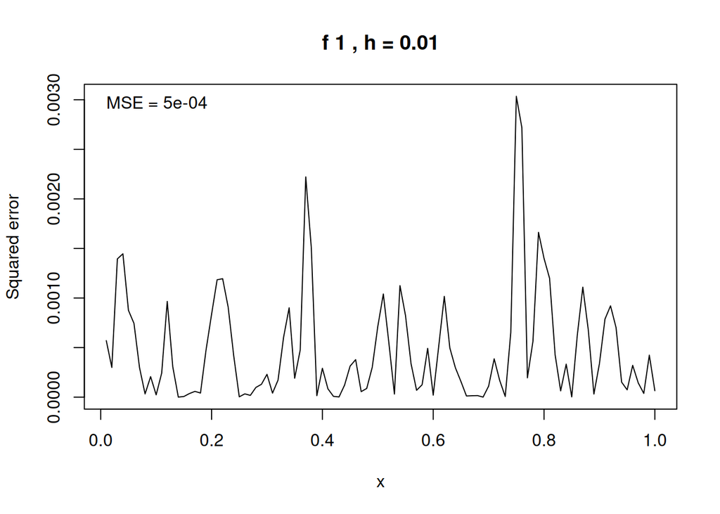

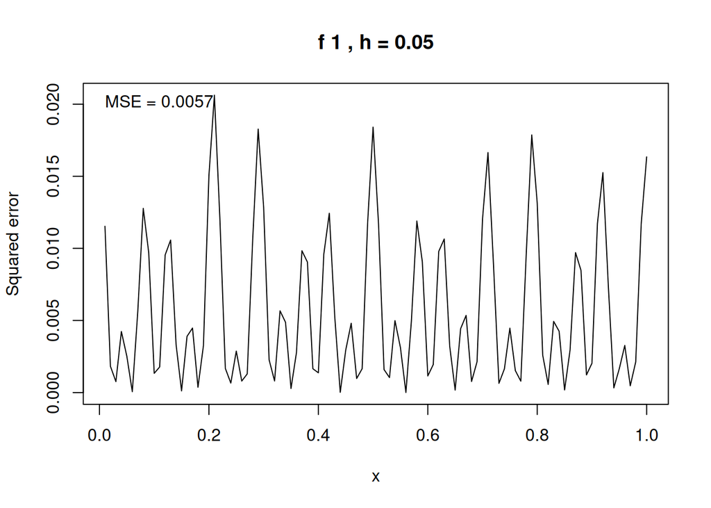

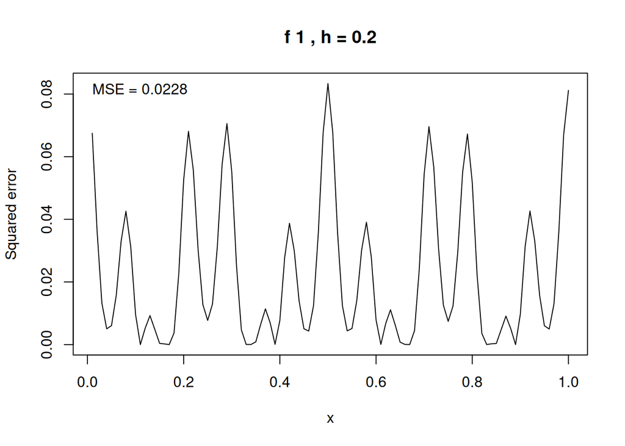

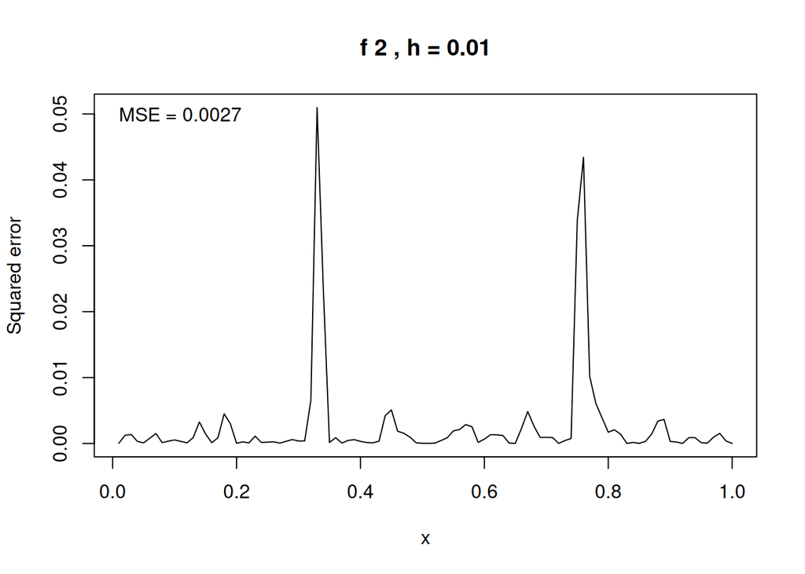

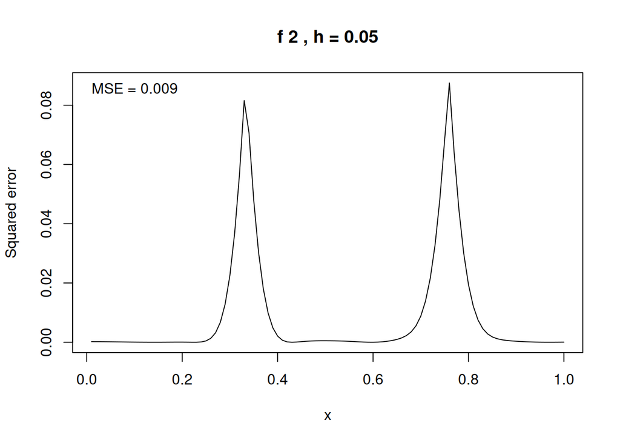

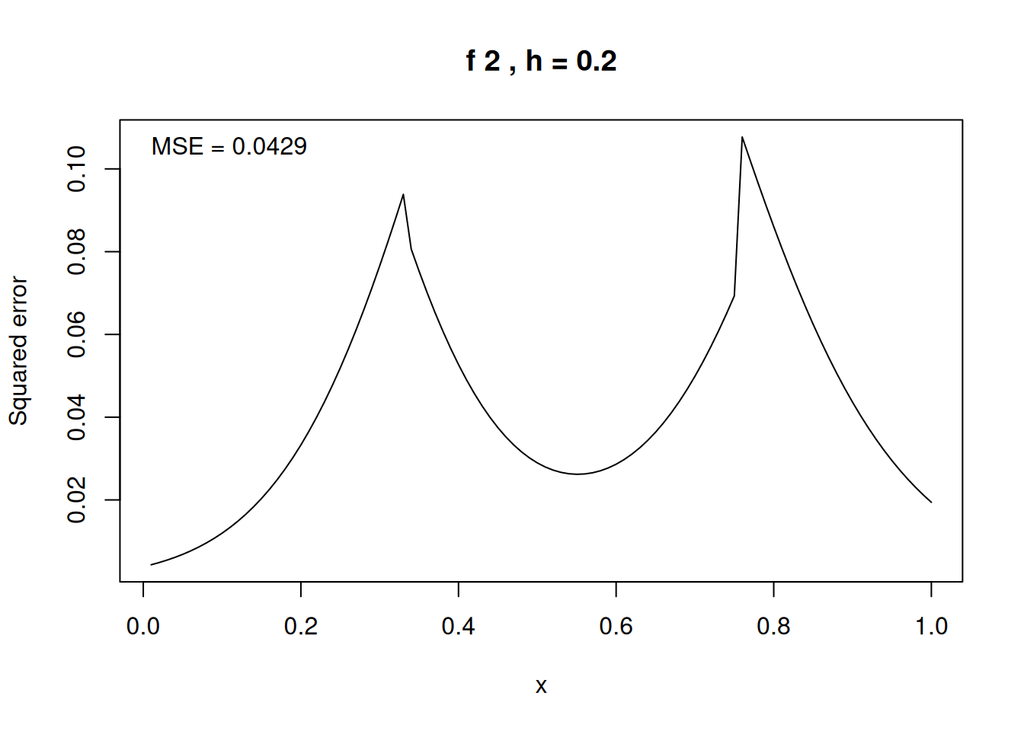

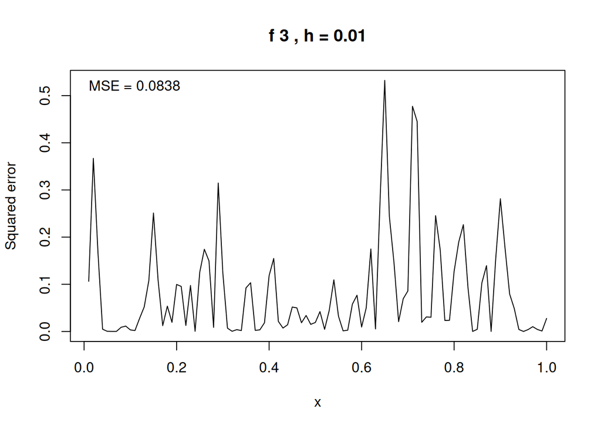

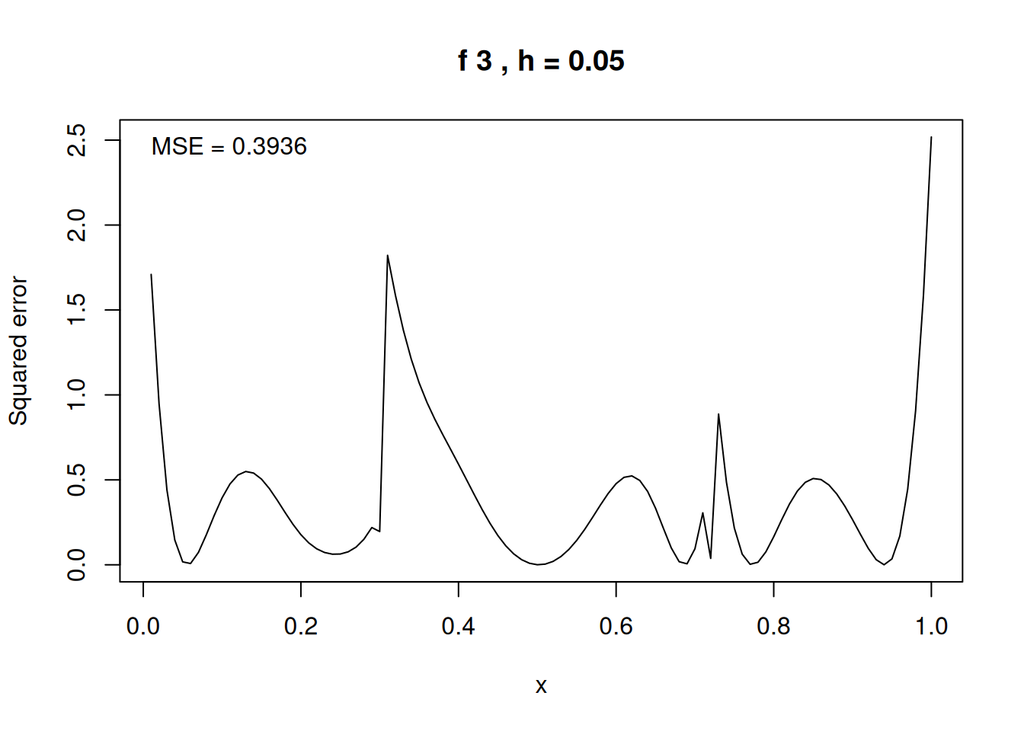

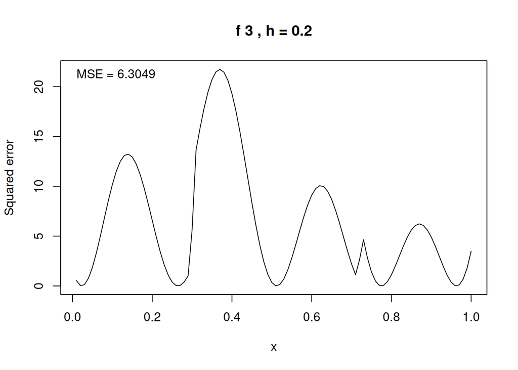

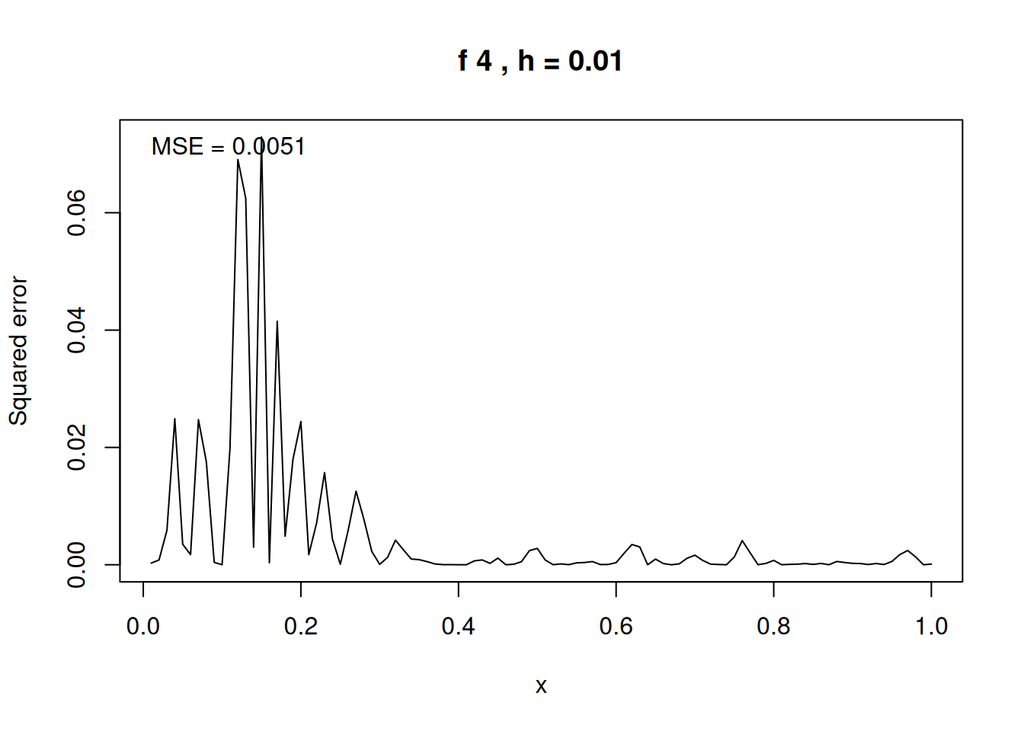

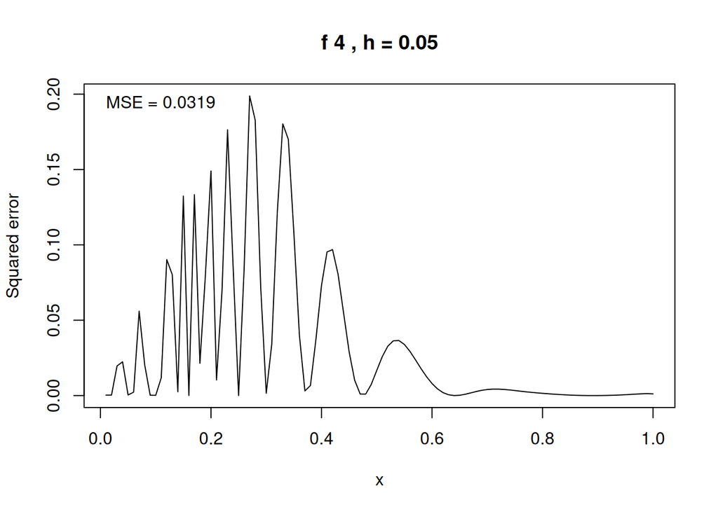

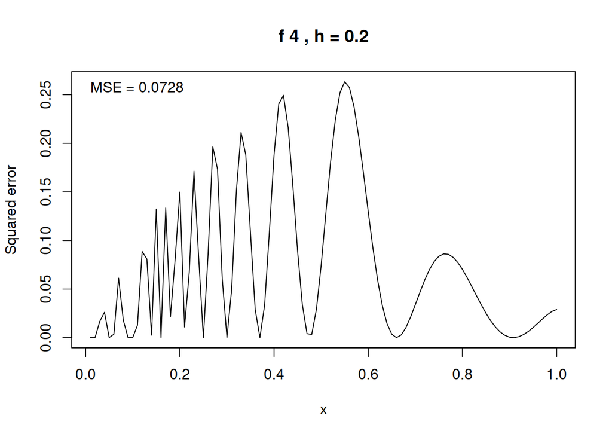

```r
hvals <- c(0.01, 0.05, 0.2)

Ylist <- list(Y1, Y2, Y3, Y4)
flist <- list(f1, f2, f3, f4)

for (j in 1:length(Ylist)) {

  Yj <- Ylist[[j]]
  fj <- flist[[j]]

  for (h in hvals) {

    fit <- locpoly(x, Yj, bandwidth = h, degree = 0, gridsize = 100)

    # pointwise squared error
    err <- (fit$y - fj)^2

    # mean squared error
    mse <- mean(err)

    plot(fit$x, err, type = "l",
         main = paste("f", j, ", h =", h),
         ylab = "Squared error",
         xlab = "x")

    # MSE value
    text(x = min(fit$x),
         y = max(err),
         labels = paste("MSE =", round(mse, 4)),
         adj = c(0, 1))
  }
}
```

Increasing the value of h also increases the MSE. However a very small MSE could suggest over fitting so it is better to choose a neither too small nor too large h.

## Part III

What do you find about the bias and variance of the estimators as h varies ?

### Answer:

As h increases, the variance of the kernel estimator decreases while its bias increases. Small bandwidths lead to noisy but close to accurate estimates, whereas large bandwidths produce smooth but biased estimates.

# Question 4

What can you say about the quality of the choice of h by cross-validation for the estimation of the regression functions $f_1$ , . . . , $f_4$ ?

```r
bw1 <- dpill(x, Y1)
bw2 <- dpill(x, Y2)
bw3 <- dpill(x, Y3)
bw4 <- dpill(x, Y4)

bw1; bw2; bw3; bw4
```

```
## [1] 0.03756561
```

```
## [1] 0.02419233
```

```
## [1] 0.02312501
```

```
## [1] 0.02322242
```

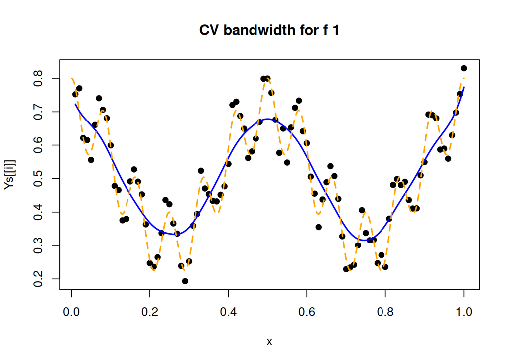

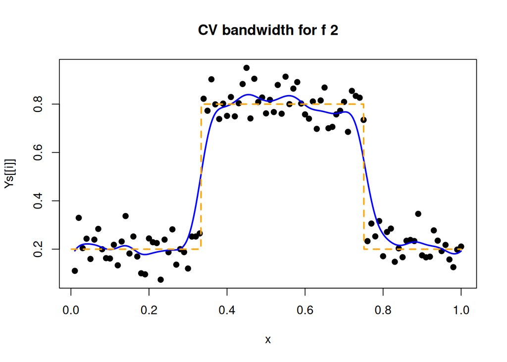

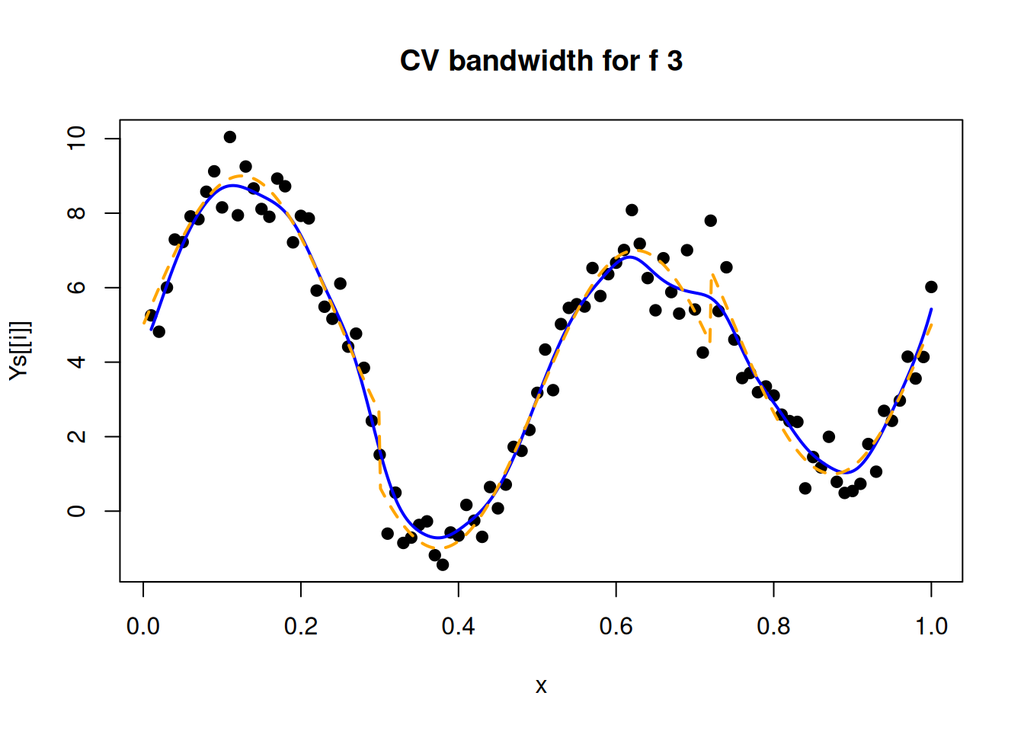

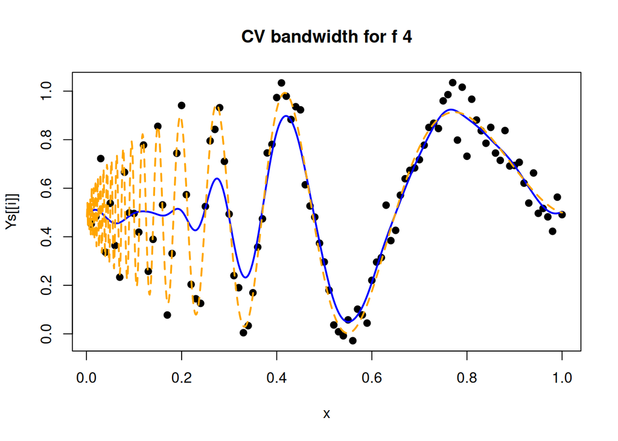

```r
fits <- list(
  locpoly(x,Y1,bandwidth=bw1),
  locpoly(x,Y2,bandwidth=bw2),
  locpoly(x,Y3,bandwidth=bw3),
  locpoly(x,Y4,bandwidth=bw4)
)

truefs <- list(truef1,truef2,truef3,truef4)
Ys <- list(Y1,Y2,Y3,Y4)

for (i in 1:4) {
  plot(x, Ys[[i]], pch=19, col="black",
       main=paste("CV bandwidth for f",i))
  lines(fits[[i]], col="blue", lwd=2)
  lines(t, truefs[[i]], col="orange", lwd=2, lty=2)
}
```